# Evaluating Intragenomic Conflict in the Altruistic, Pheromone-Mediated Retinue Behavior in Honey Bees: parent-specific gene expression analysis

Sean Bresnahan

2023-06-02

F1 Read counts and BED files of F0 variants are imported.

SNPs intersecting $n > 2$ genes, $n = 2$ genes annotated on the same strand, or within mitochondrial, miRNA, or tRNA genes are discarded.

SNPs with $n < 10$ read counts in any Lineage; SNPs where the distance between the nearest SNP is shorter than the average read length (thus the read counts are exactly the same for both SNPs), and genes with $n < 2$ SNPs are discarded.

To adjust for differences in sequencing depth between libraries, read counts are normalized using the median of ratios normalization (MRN) method from DESeq2.

For each SNP, a Storer-Kim binomial exact test of two proportions is conducted using the MRN normalized counts to test the hypothesis that the proportion of maternal read counts is significantly different from the proportion of paternal read counts.

Previously established cutoffs for p1 (the proportion of “A” allele counts in individuals from the “BxA” Lineage) and p2 (the proportion of “A” allele counts in individuals from the “AxB” Lineage) are required for a gene to be considered as showing parent or lineage bias.

A general linear mixed-effects model (GLIMMIX) is fit for each gene to assess the effects of parent, lineage, and their interaction on the quantity of raw read counts at each SNP, using the library size factors estimated during MRN normalization as an offset to adjust for variation in sequencing depth between samples. Genes exhibiting significant parent∗lineage effects are considered unbiased.

For a gene to be considered as showing parent or lineage biases, all SNPs are required to exhibit the same directional bias in both tests.

This analysis utilizes several custom functions. [See here for documentation.](https://github.com/sbresnahan/IGC-retinue/blob/main/PSGE_functions.R)

# Requirements

```r
# Packages
library(tidyverse)
library(plyr)
library(Rfast)
library(tryCatchLog)
library(lmerTest)
library(lme4)
library(car)
library(gridExtra)
library(kableExtra)
library(doParallel)
library(ggpubr)
library(grid)
library(tagcloud)
library(DESeq2)
library(ggprism)
# Custom functions
source("PSGE_functions.R")
```

# Y12xO20

### Sample metadata

```r
metadata <- read.csv("metadata.csv")
metadata <- metadata[metadata$block=="Y12xO20",]
kbl(metadata) %>% kable_styling()
```

|  | sample.id | parent | phenotype | individual | lineage | block |
| --- | --- | --- | --- | --- | --- | --- |
| 13 | Y12D_SRR24049740 | D | responsive | Y12-R1 | A | Y12xO20 |
| 14 | Y12D_SRR24049739 | D | responsive | Y12-R2 | A | Y12xO20 |
| 15 | Y12D_SRR24049738 | D | responsive | Y12-R3 | A | Y12xO20 |
| 16 | Y12D_SRR24049737 | D | unresponsive | Y12-U1 | A | Y12xO20 |
| 17 | Y12D_SRR24049735 | D | unresponsive | Y12-U2 | A | Y12xO20 |
| 18 | Y12D_SRR24049734 | D | unresponsive | Y12-U3 | A | Y12xO20 |
| 19 | O20D_SRR24049753 | D | responsive | O20-R1 | B | Y12xO20 |
| 20 | O20D_SRR24049752 | D | responsive | O20-R2 | B | Y12xO20 |
| 21 | O20D_SRR24049751 | D | responsive | O20-R3 | B | Y12xO20 |
| 22 | O20D_SRR24049750 | D | unresponsive | O20-U1 | B | Y12xO20 |
| 23 | O20D_SRR24049749 | D | unresponsive | O20-U2 | B | Y12xO20 |
| 24 | O20D_SRR24049748 | D | unresponsive | O20-U3 | B | Y12xO20 |
| 49 | Y12Q_SRR24049740 | Q | responsive | Y12-R1 | A | Y12xO20 |
| 50 | Y12Q_SRR24049739 | Q | responsive | Y12-R2 | A | Y12xO20 |
| 51 | Y12Q_SRR24049738 | Q | responsive | Y12-R3 | A | Y12xO20 |
| 52 | Y12Q_SRR24049737 | Q | unresponsive | Y12-U1 | A | Y12xO20 |
| 53 | Y12Q_SRR24049735 | Q | unresponsive | Y12-U2 | A | Y12xO20 |
| 54 | Y12Q_SRR24049734 | Q | unresponsive | Y12-U3 | A | Y12xO20 |
| 55 | O20Q_SRR24049753 | Q | responsive | O20-R1 | B | Y12xO20 |
| 56 | O20Q_SRR24049752 | Q | responsive | O20-R2 | B | Y12xO20 |
| 57 | O20Q_SRR24049751 | Q | responsive | O20-R3 | B | Y12xO20 |
| 58 | O20Q_SRR24049750 | Q | unresponsive | O20-U1 | B | Y12xO20 |
| 59 | O20Q_SRR24049749 | Q | unresponsive | O20-U2 | B | Y12xO20 |
| 60 | O20Q_SRR24049748 | Q | unresponsive | O20-U3 | B | Y12xO20 |

### Generate SNP:gene read coverage matrix [`filter_SNPs`]

1. Filter SNPs that overlap > 2 genes
2. Filter SNPs overlapping 2 genes on the same strand
3. Filter SNPs within miRNA/tRNA genes

#### Filter SNPs

```r
filterlist <- read.csv("miRNA_tRNA_genes.csv",header=F)[,c(1)]
SNPs <- filter_SNPs("Y12xO20_SNPs_for_analysis_sorted.bed",filterlist,2)
write.table(SNPs,"Y12xO20_SNP_gene_overlaps.txt",sep="\t",quote=F,row.names=F)
SNPs <- SNPs[,c(3,4)]
```

#### Combine coverage files to single matrix [`make_ASE_counts_matrix`]

1. Left join read coverage files by SNP:gene
2. Remove duplicate rows within genes (where counts are the same at multiple SNPs aLineage samples).

```r
SNP_counts <- make_ASE_counts_matrix("counts",metadata,12)
write.csv(SNP_counts,"Y12xO20_SNP_gene_counts.csv")
```

### Normalize counts by library size

Here, we normalize the read counts to adjust for variation in sequencing depth between samples. We will conduct the Storer-Kim binomial exact test of two proportions at each SNP using the normalized read counts, and then fit gene-wise general linear mixed-effects models to the raw read counts at each SNP, adjusting for library size by including the library size factors calculated during the normalization step as an offset term in the model.

1. Merge allelic counts by library and estimate library size factors using the median of ratios normalization method from DESeq2 [`calcSizeFactors`]
2. Normalize counts for each library by allele [`normalizeASReadCounts`]

```r
size_factors <- calcSizeFactors(SNP_counts,metadata)
SNP_counts_normalized <- normalizeASReadCounts(SNP_counts,metadata,size_factors)
write.csv(SNP_counts_normalized,"Y12xO20_SNP_gene_counts_normalized.csv")
```

### Process count matrices for each phenotype

#### Split raw and normalized count matrices by phenotype

```r
unresponsive.IDs <- metadata[metadata$phenotype=="unresponsive","sample.id"]
responsive.IDs <- metadata[metadata$phenotype=="responsive","sample.id"]

unresponsive_counts_normalized <- SNP_counts_normalized[,names(SNP_counts_normalized)%in%unresponsive.IDs]
unresponsive_counts <- SNP_counts[row.names(SNP_counts)%in%row.names(unresponsive_counts_normalized),
                                  names(SNP_counts)%in%unresponsive.IDs]

responsive_counts_normalized <- SNP_counts_normalized[,names(SNP_counts_normalized)%in%responsive.IDs]
responsive_counts <- SNP_counts[row.names(SNP_counts)%in%row.names(responsive_counts_normalized),
                                names(SNP_counts)%in%responsive.IDs]
```

#### Filter low-count SNPs from count matrix [`filter_counts`]

1. Remove rows with 0 counts by Lineage
2. Flag rows with > 10000 read counts (we run an optimized version of the binomial exact test on these rows, as the binom.test function cannot handle counts > 10000)
3. Remove genes with < 2 SNPs after steps 1 and 2

```r
unresponsive_counts_normalized <- filter_counts(unresponsive_counts_normalized,metadata,9)
write.csv(unresponsive_counts_normalized,"Y12xO20_unresponsive_counts_normalized.csv")
unresponsive_counts <- unresponsive_counts[row.names(unresponsive_counts)%in%row.names(unresponsive_counts_normalized),]
write.csv(unresponsive_counts,"Y12xO20_unresponsive_counts.csv")

responsive_counts_normalized <- filter_counts(responsive_counts_normalized,metadata,9)
write.csv(responsive_counts_normalized,"Y12xO20_responsive_counts_normalized.csv")
responsive_counts <- responsive_counts[row.names(responsive_counts)%in%row.names(responsive_counts_normalized),]
write.csv(responsive_counts,"Y12xO20_responsive_counts.csv")
```

### Conduct statistical tests

#### Storer-Kim binomial exact test of two proportions for each SNP [`PSGE.SK`]

```r
unresponsive.SK <- PSGE.SK(unresponsive_counts_normalized,metadata,"unresponsive",12)
write.csv(unresponsive.SK,"Y12xO20_unresponsiveSK.csv", row.names=F)

responsive.SK <- PSGE.SK(responsive_counts_normalized,metadata,"responsive",12)
write.csv(responsive.SK,"Y12xO20_responsiveSK.csv", row.names=F)
```

#### Fit GLIMMIX for each gene [`PSGE.GLIMMIX`]

```r
unresponsive.GLIMMIX <- PSGE.GLIMMIX(unresponsive_counts,metadata,
                                     size_factors,12)
write.csv(unresponsive.GLIMMIX,"Y12xO20_unresponsiveGLIMMIX.csv", row.names=F)

responsive.GLIMMIX <- PSGE.GLIMMIX(responsive_counts,metadata,
                                   size_factors,12)
write.csv(responsive.GLIMMIX,"Y12xO20_responsiveGLIMMIX.csv", row.names=F)
```

### Assess test results for each gene [`PSGE.analysis`]

1. Split count matrices by Lineage and parent of origin for plotting
2. Set up a data.frame to plot %p1 and %p2 for each SNP
3. Join results of Storer-Kim tests
4. Join results of GLIMMIX models
5. Correct for multiple testing
6. For each gene, check whether all SNPs are biased in the same direction
7. Genes with parentXLineage effects are flagged as unbiased

```r
unresponsive.plot <- PSGE.analysis(unresponsive_counts_normalized,
                                   "unresponsive",metadata,
                                   unresponsive.SK,unresponsive.GLIMMIX)
write.csv(unresponsive.plot,"Y12xO20_unresponsive_PSGE.csv",row.names=F)

responsive.plot <- PSGE.analysis(responsive_counts_normalized,
                                 "responsive",metadata,
                                 responsive.SK,responsive.GLIMMIX)
write.csv(responsive.plot,"Y12xO20_responsive_PSGE.csv",row.names=F)
```

### Plot PSGE by transcript

1. Collapse SNPs to calculate p1 & p2 by transcript [`PSGE.collapse.avgExp`]
2. Generate PSGE plot, averaging p1 & p2 by transcript [`PSGE.plot.tx`]
3. Make center table [`triplot.plot`]

#### Unresponsive

```r
unresponsive_counts_normalized <- read.csv("Y12xO20_unresponsive_counts_normalized.csv",
                                           row.names=1)
unresponsive.plot <- read.csv("Y12xO20_unresponsive_PSGE.csv")
unresponsive.plot[is.na(unresponsive.plot$xbias),"xbias"] <- "NA"
unresponsive.plot[is.na(unresponsive.plot$bias),"bias"] <- "NA"
unresponsive.plot[is.na(unresponsive.plot$bias.plot),"bias.plot"] <- "NA"
unresponsive.plot <- rbind(unresponsive.plot[unresponsive.plot$
                                               bias.plot%in%c("NA"),],
                           unresponsive.plot[unresponsive.plot$bias.plot%in%c(
                             "mat", "Lineage A", "Lineage B", "pat"),])
unresponsive.plot$bias.plot <- factor(unresponsive.plot$bias.plot,
                                      levels = c("NA","mat", "Lineage A", "Lineage B", "pat"))

unresponsive.collapse <- PSGE.collapse.avgExp(unresponsive.plot,
                                              unresponsive_counts_normalized,
                                              metadata,"unresponsive")
g1.avgExp <- PSGE.plot.tx(unresponsive.collapse,"Unresponsive",
                          LineageA.color.dark="#b697f7",LineageA.color.light="#bfc1ff",
                          LineageB.color.dark="#f7af09",LineageB.color.light="#f7c95e")
```

#### Responsive

```r
responsive_counts_normalized <- read.csv("Y12xO20_responsive_counts_normalized.csv",
                                           row.names=1)
responsive.plot <- read.csv("Y12xO20_responsive_PSGE.csv")
responsive.plot[is.na(responsive.plot$xbias),"xbias"] <- "NA"
responsive.plot[is.na(responsive.plot$bias),"bias"] <- "NA"
responsive.plot[is.na(responsive.plot$bias.plot),"bias.plot"] <- "NA"
responsive.plot <- rbind(responsive.plot[responsive.plot$bias.plot%in%c("NA"),],
                         responsive.plot[responsive.plot$bias.plot%in%c(
                           "mat", "Lineage A", "Lineage B", "pat"),])
responsive.plot$bias.plot <- factor(responsive.plot$bias.plot,
                                    levels = c("NA","mat", "Lineage A", "Lineage B", "pat"))

responsive.collapse <- PSGE.collapse.avgExp(responsive.plot,
                                            responsive_counts_normalized,
                                            metadata,"responsive")
g2.avgExp <- PSGE.plot.tx(responsive.collapse,"Responsive",
                          LineageA.color.dark="#b697f7",LineageA.color.light="#bfc1ff",
                          LineageB.color.dark="#f7af09",LineageB.color.light="#f7c95e")
```

#### Join results and generate final plot

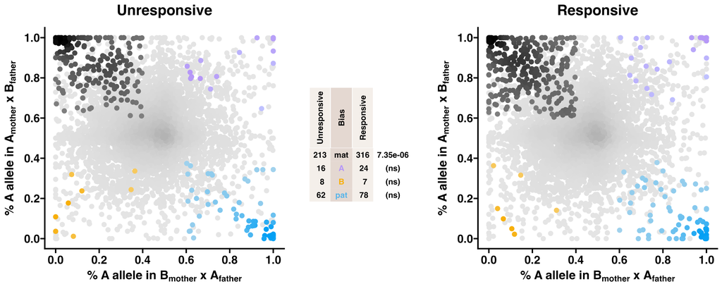

```r
allgenes <- read.table("Amel_HAv3.1_genes.bed",header=F)[,c(4)]
triplot.avgExp <- triplot.plot(unresponsive.collapse,responsive.collapse,
                               "Unresponsive","Responsive",allgenes,
                               LineageA.color="#b697f7",LineageB.color="#f7af09")
fig1.avgExp <- arrangeGrob(g1.avgExp, triplot.avgExp,
                           g2.avgExp, widths=c(5,2.5,5))
ggsave(file="Y12xO20_avgExp.png", plot=fig1.avgExp, width=15, height=6)
```

### Export PSGE gene lists [`export_PSGE_results`]

```r
export_PSGE_results(unresponsive.plot,responsive.plot,"Y12xO20_PSGEs.csv")
```

# B4xW36

### Sample metadata

```r
metadata <- read.csv("metadata.csv")
metadata <- metadata[metadata$block=="B4xW36",]
kbl(metadata) %>% kable_styling()
```

|  | sample.id | parent | phenotype | individual | lineage | block |
| --- | --- | --- | --- | --- | --- | --- |
| 25 | B4D_SRR24049729 | D | responsive | B4-R1 | A | B4xW36 |
| 26 | B4D_SRR24049728 | D | responsive | B4-R2 | A | B4xW36 |
| 27 | B4D_SRR24049757 | D | responsive | B4-R3 | A | B4xW36 |
| 28 | B4D_SRR24049756 | D | unresponsive | B4-U1 | A | B4xW36 |
| 29 | B4D_SRR24049755 | D | unresponsive | B4-U2 | A | B4xW36 |
| 30 | B4D_SRR24049754 | D | unresponsive | B4-U3 | A | B4xW36 |
| 31 | W36D_SRR24049746 | D | responsive | W36-R1 | B | B4xW36 |
| 32 | W36D_SRR24049745 | D | responsive | W36-R2 | B | B4xW36 |
| 33 | W36D_SRR24049744 | D | responsive | W36-R3 | B | B4xW36 |
| 34 | W36D_SRR24049743 | D | unresponsive | W36-U1 | B | B4xW36 |
| 35 | W36D_SRR24049742 | D | unresponsive | W36-U2 | B | B4xW36 |
| 36 | W36D_SRR24049741 | D | unresponsive | W36-U3 | B | B4xW36 |
| 61 | B4Q_SRR24049729 | Q | responsive | B4-R1 | A | B4xW36 |
| 62 | B4Q_SRR24049728 | Q | responsive | B4-R2 | A | B4xW36 |
| 63 | B4Q_SRR24049757 | Q | responsive | B4-R3 | A | B4xW36 |
| 64 | B4Q_SRR24049756 | Q | unresponsive | B4-U1 | A | B4xW36 |
| 65 | B4Q_SRR24049755 | Q | unresponsive | B4-U2 | A | B4xW36 |
| 66 | B4Q_SRR24049754 | Q | unresponsive | B4-U3 | A | B4xW36 |
| 67 | W36Q_SRR24049746 | Q | responsive | W36-R1 | B | B4xW36 |
| 68 | W36Q_SRR24049745 | Q | responsive | W36-R2 | B | B4xW36 |
| 69 | W36Q_SRR24049744 | Q | responsive | W36-R3 | B | B4xW36 |
| 70 | W36Q_SRR24049743 | Q | unresponsive | W36-U1 | B | B4xW36 |
| 71 | W36Q_SRR24049742 | Q | unresponsive | W36-U2 | B | B4xW36 |
| 72 | W36Q_SRR24049741 | Q | unresponsive | W36-U3 | B | B4xW36 |

### Generate SNP:gene read coverage matrix

#### Filter SNPs [`filter_SNPs`]

1. Filter SNPs that overlap > 2 genes
2. Filter SNPs overlapping 2 genes on the same strand
3. Filter SNPs within miRNA/tRNA genes

```r
filterlist <- read.csv("miRNA_tRNA_genes.csv",header=F)[,c(1)]
SNPs <- filter_SNPs("B4xW36_SNPs_for_analysis_sorted.bed",filterlist,2)
write.table(SNPs,"B4xW36_SNP_gene_overlaps.txt",sep="\t",quote=F,row.names=F)
SNPs <- SNPs[,c(3,4)]
```

#### Combine coverage files to single matrix [`make_ASE_counts_matrix`]

1. Left join read coverage files by SNP:gene
2. Remove duplicate rows within genes (where counts are the same at multiple SNPs aLineage samples).

```r
SNP_counts <- make_ASE_counts_matrix("counts",metadata,12)
write.csv(SNP_counts,"B4xW36_SNP_gene_counts.csv")
```

### Normalize counts by library size

Here, we normalize the read counts to adjust for variation in sequencing depth between samples. We will conduct the Storer-Kim binomial exact test of two proportions at each SNP using the normalized read counts, and then fit gene-wise general linear mixed-effects models to the raw read counts at each SNP, adjusting for library size by including the library size factors calculated during the normalization step as an offset term in the model.

1. Merge allelic counts by library and estimate library size factors using the median of ratios normalization method from DESeq2 [`calcSizeFactors`]
2. Normalize counts for each library by allele [`normalizeASReadCounts`]

```r
size_factors <- calcSizeFactors(SNP_counts,metadata)
SNP_counts_normalized <- normalizeASReadCounts(SNP_counts,metadata,size_factors)
write.csv(SNP_counts_normalized,"B4xW36_SNP_gene_counts_normalized.csv")
```

### Process count matrices for each phenotype

#### Split raw and normalized count matrices by phenotype

```r
unresponsive.IDs <- metadata[metadata$phenotype=="unresponsive","sample.id"]
responsive.IDs <- metadata[metadata$phenotype=="responsive","sample.id"]

unresponsive_counts_normalized <- SNP_counts_normalized[,names(SNP_counts_normalized)%in%unresponsive.IDs]
unresponsive_counts <- SNP_counts[row.names(SNP_counts)%in%row.names(unresponsive_counts_normalized),
                                  names(SNP_counts)%in%unresponsive.IDs]

responsive_counts_normalized <- SNP_counts_normalized[,names(SNP_counts_normalized)%in%responsive.IDs]
responsive_counts <- SNP_counts[row.names(SNP_counts)%in%row.names(responsive_counts_normalized),
                                names(SNP_counts)%in%responsive.IDs]
```

#### Filter low-count SNPs from count matrix [`filter_counts`]

1. Remove rows with 0 counts by Lineage
2. Flag rows with > 10000 read counts (we run an optimized version of the binomial exact test on these rows, as the binom.test function cannot handle counts > 10000)
3. Remove genes with < 2 SNPs after steps 1 and 2

```r
unresponsive_counts_normalized <- filter_counts(unresponsive_counts_normalized,metadata,9)
write.csv(unresponsive_counts_normalized,"B4xW36_unresponsive_counts_normalized.csv")
unresponsive_counts <- unresponsive_counts[row.names(unresponsive_counts)%in%row.names(unresponsive_counts_normalized),]
write.csv(unresponsive_counts,"B4xW36_unresponsive_counts.csv")

responsive_counts_normalized <- filter_counts(responsive_counts_normalized,metadata,9)
write.csv(responsive_counts_normalized,"B4xW36_responsive_counts_normalized.csv")
responsive_counts <- responsive_counts[row.names(responsive_counts)%in%row.names(responsive_counts_normalized),]
write.csv(responsive_counts,"B4xW36_responsive_counts.csv")
```

### Conduct statistical tests

#### Storer-Kim binomial exact test of two proportions for each SNP [`PSGE.SK`]

```r
unresponsive.SK <- PSGE.SK(unresponsive_counts_normalized,metadata,"unresponsive",14)
write.csv(unresponsive.SK,"B4xW36_unresponsiveSK.csv", row.names=F)

responsive.SK <- PSGE.SK(responsive_counts_normalized,metadata,"responsive",14)
write.csv(responsive.SK,"B4xW36_responsiveSK.csv", row.names=F)
```

#### Fit GLIMMIX for each gene [`PSGE.GLIMMIX`]

```r
unresponsive.GLIMMIX <- PSGE.GLIMMIX(unresponsive_counts,metadata,
                                     size_factors,14)
write.csv(unresponsive.GLIMMIX,"B4xW36_unresponsiveGLIMMIX.csv", row.names=F)

responsive.GLIMMIX <- PSGE.GLIMMIX(responsive_counts,metadata,
                                   size_factors,14)
write.csv(responsive.GLIMMIX,"B4xW36_responsiveGLIMMIX.csv", row.names=F)
```

### Assess test results for each gene [`PSGE.analysis`]

1. Split count matrices by Lineage and parent of origin for plotting
2. Set up a data.frame to plot %p1 and %p2 for each SNP
3. Join results of Storer-Kim tests
4. Join results of GLIMMIX models
5. Correct for multiple testing
6. For each gene, check whether all SNPs are biased in the same direction
7. Genes with parentXLineage effects are flagged as unbiased

```r
unresponsive.plot <- PSGE.analysis(unresponsive_counts_normalized,
                                   "unresponsive",metadata,
                                   unresponsive.SK,unresponsive.GLIMMIX)
write.csv(unresponsive.plot,"B4xW36_unresponsive_PSGE.csv",row.names=F)

responsive.plot <- PSGE.analysis(responsive_counts_normalized,
                                 "responsive",metadata,
                                 responsive.SK,responsive.GLIMMIX)
write.csv(responsive.plot,"B4xW36_responsive_PSGE.csv",row.names=F)
```

### Plot PSGE by transcript

1. Collapse SNPs to calculate p1 & p2 by transcript [`PSGE.collapse.avgExp`]
2. Generate PSGE plot, averaging p1 & p2 by transcript [`PSGE.plot.tx`]
3. Make center table [`triplot.plot`]

#### Unresponsive

```r
unresponsive_counts_normalized <- read.csv("B4xW36_unresponsive_counts_normalized.csv",
                                           row.names=1)
unresponsive.plot <- read.csv("B4xW36_unresponsive_PSGE.csv")
unresponsive.plot[is.na(unresponsive.plot$xbias),"xbias"] <- "NA"
unresponsive.plot[is.na(unresponsive.plot$bias),"bias"] <- "NA"
unresponsive.plot[is.na(unresponsive.plot$bias.plot),"bias.plot"] <- "NA"
unresponsive.plot <- rbind(unresponsive.plot[unresponsive.plot$
                                               bias.plot%in%c("NA"),],
                           unresponsive.plot[unresponsive.plot$bias.plot%in%c(
                             "mat", "Lineage A", "Lineage B", "pat"),])
unresponsive.plot$bias.plot <- factor(unresponsive.plot$bias.plot,
                                      levels = c("NA","mat", "Lineage A", "Lineage B", "pat"))

unresponsive.collapse <- PSGE.collapse.avgExp(unresponsive.plot,
                                              unresponsive_counts_normalized,
                                              metadata,"unresponsive")
g1.avgExp <- PSGE.plot.tx(unresponsive.collapse,"Unresponsive",
                          LineageA.color.dark="#ff7e79",LineageA.color.light="#fc9895",
                          LineageB.color.dark="#f7af09",LineageB.color.light="#f7c95e")
```

#### Responsive

```r
responsive_counts_normalized <- read.csv("B4xW36_responsive_counts_normalized.csv",
                                           row.names=1)
responsive.plot <- read.csv("B4xW36_responsive_PSGE.csv")
responsive.plot[is.na(responsive.plot$xbias),"xbias"] <- "NA"
responsive.plot[is.na(responsive.plot$bias),"bias"] <- "NA"
responsive.plot[is.na(responsive.plot$bias.plot),"bias.plot"] <- "NA"
responsive.plot <- rbind(responsive.plot[responsive.plot$bias.plot%in%c("NA"),],
                         responsive.plot[responsive.plot$bias.plot%in%c(
                           "mat", "Lineage A", "Lineage B", "pat"),])
responsive.plot$bias.plot <- factor(responsive.plot$bias.plot,
                                    levels = c("NA","mat", "Lineage A", "Lineage B", "pat"))

responsive.collapse <- PSGE.collapse.avgExp(responsive.plot,
                                            responsive_counts_normalized,
                                            metadata,"responsive")
g2.avgExp <- PSGE.plot.tx(responsive.collapse,"Responsive",
                          LineageA.color.dark="#ff7e79",LineageA.color.light="#fc9895",
                          LineageB.color.dark="#f7af09",LineageB.color.light="#f7c95e")
```

#### Join results and generate final plot

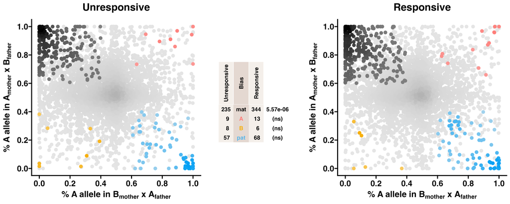

```r
allgenes <- read.table("Amel_HAv3.1_genes.bed",header=F)[,c(4)]
triplot.avgExp <- triplot.plot(unresponsive.collapse,responsive.collapse,
                               "Unresponsive","Responsive",allgenes,
                               LineageA.color="#ff7e79",LineageB.color="#f7af09")
fig1.avgExp <- arrangeGrob(g1.avgExp, triplot.avgExp,
                           g2.avgExp, widths=c(5,2.5,5))
ggsave(file="B4xW36_avgExp.png", plot=fig1.avgExp, width=15, height=6)
```

### Export PSGE gene lists

```r
export_PSGE_results(unresponsive.plot,responsive.plot,"B4xW36_PSGEs.csv")
```

# LB11xW4

### Sample metadata

```r
metadata <- read.csv("metadata.csv")
metadata <- metadata[metadata$block=="LB11xW4",]
kbl(metadata) %>% kable_styling()
```

|  | sample.id | parent | phenotype | individual | lineage | block |
| --- | --- | --- | --- | --- | --- | --- |
| 1 | LB11D_SRR14654185 | D | responsive | LB11-R1 | A | LB11xW4 |
| 2 | LB11D_SRR14654181 | D | responsive | LB11-R2 | A | LB11xW4 |
| 3 | LB11D_SRR14654179 | D | responsive | LB11-R3 | A | LB11xW4 |
| 4 | LB11D_SRR14654184 | D | unresponsive | LB11-U1 | A | LB11xW4 |
| 5 | LB11D_SRR14654180 | D | unresponsive | LB11-U2 | A | LB11xW4 |
| 6 | LB11D_SRR14654178 | D | unresponsive | LB11-U3 | A | LB11xW4 |
| 7 | W4D_SRR14654177 | D | responsive | W4-R1 | B | LB11xW4 |
| 8 | W4D_SRR14654175 | D | responsive | W4-R2 | B | LB11xW4 |
| 9 | W4D_SRR14654183 | D | responsive | W4-R3 | B | LB11xW4 |
| 10 | W4D_SRR14654176 | D | unresponsive | W4-U1 | B | LB11xW4 |
| 11 | W4D_SRR14654174 | D | unresponsive | W4-U2 | B | LB11xW4 |
| 12 | W4D_SRR14654182 | D | unresponsive | W4-U3 | B | LB11xW4 |
| 37 | LB11Q_SRR14654185 | Q | responsive | LB11-R1 | A | LB11xW4 |
| 38 | LB11Q_SRR14654181 | Q | responsive | LB11-R2 | A | LB11xW4 |
| 39 | LB11Q_SRR14654179 | Q | responsive | LB11-R3 | A | LB11xW4 |
| 40 | LB11Q_SRR14654184 | Q | unresponsive | LB11-U1 | A | LB11xW4 |
| 41 | LB11Q_SRR14654180 | Q | unresponsive | LB11-U2 | A | LB11xW4 |
| 42 | LB11Q_SRR14654178 | Q | unresponsive | LB11-U3 | A | LB11xW4 |
| 43 | W4Q_SRR14654177 | Q | responsive | W4-R1 | B | LB11xW4 |
| 44 | W4Q_SRR14654175 | Q | responsive | W4-R2 | B | LB11xW4 |
| 45 | W4Q_SRR14654183 | Q | responsive | W4-R3 | B | LB11xW4 |
| 46 | W4Q_SRR14654176 | Q | unresponsive | W4-U1 | B | LB11xW4 |
| 47 | W4Q_SRR14654174 | Q | unresponsive | W4-U2 | B | LB11xW4 |
| 48 | W4Q_SRR14654182 | Q | unresponsive | W4-U3 | B | LB11xW4 |

### Generate SNP:gene read coverage matrix

#### Filter SNPs [`filter_SNPs`]

1. Filter SNPs that overlap > 2 genes
2. Filter SNPs overlapping 2 genes on the same strand
3. Filter SNPs within miRNA/tRNA genes

```r
filterlist <- read.csv("miRNA_tRNA_genes.csv",header=F)[,c(1)]
SNPs <- filter_SNPs("LB11xW4_SNPs_for_analysis_sorted.bed",filterlist,12)
write.table(SNPs,"LB11xW4_SNP_gene_overlaps.txt",sep="\t",quote=F,row.names=F)
SNPs <- SNPs[,c(3,4)]
```

#### Combine coverage files to single matrix [`make_ASE_counts_matrix`]

1. Left join read coverage files by SNP:gene
2. Remove duplicate rows within genes (where counts are the same at multiple SNPs aLineage samples).

```r
SNP_counts <- make_ASE_counts_matrix("counts",metadata,12)
write.csv(SNP_counts,"LB11xW4_SNP_gene_counts.csv")
```

## Normalize counts by library size

Here, we normalize the read counts to adjust for variation in sequencing depth between samples. We will conduct the Storer-Kim binomial exact test of two proportions at each SNP using the normalized read counts, and then fit gene-wise general linear mixed-effects models to the raw read counts at each SNP, adjusting for library size by including the library size factors calculated during the normalization step as an offset term in the model.

1. Merge allelic counts by library and estimate library size factors using the median of ratios normalization method from DESeq2 [`calcSizeFactors`]
2. Normalize counts for each library by allele [`normalizeASReadCounts`]

```r
size_factors <- calcSizeFactors(SNP_counts,metadata)
SNP_counts_normalized <- normalizeASReadCounts(SNP_counts,metadata,size_factors)
write.csv(SNP_counts_normalized,"LB11xW4_SNP_gene_counts_normalized.csv")
```

### Process count matrices for each phenotype

#### Split raw and normalized count matrices by phenotype

```r
unresponsive.IDs <- metadata[metadata$phenotype=="unresponsive","sample.id"]
responsive.IDs <- metadata[metadata$phenotype=="responsive","sample.id"]

unresponsive_counts_normalized <- SNP_counts_normalized[,names(SNP_counts_normalized)%in%unresponsive.IDs]
unresponsive_counts <- SNP_counts[row.names(SNP_counts)%in%row.names(unresponsive_counts_normalized),
                                  names(SNP_counts)%in%unresponsive.IDs]

responsive_counts_normalized <- SNP_counts_normalized[,names(SNP_counts_normalized)%in%responsive.IDs]
responsive_counts <- SNP_counts[row.names(SNP_counts)%in%row.names(responsive_counts_normalized),
                                names(SNP_counts)%in%responsive.IDs]
```

#### Filter low-count SNPs from count matrix [`filter_counts`]

1. Remove rows with 0 counts by Lineage
2. Flag rows with > 10000 read counts (we run an optimized version of the binomial exact test on these rows, as the binom.test function cannot handle counts > 10000)
3. Remove genes with < 2 SNPs after steps 1 and 2

```r
unresponsive_counts_normalized <- filter_counts(unresponsive_counts_normalized,metadata,9)
write.csv(unresponsive_counts_normalized,"LB11xW4_unresponsive_counts_normalized.csv")
unresponsive_counts <- unresponsive_counts[row.names(unresponsive_counts)%in%row.names(unresponsive_counts_normalized),]
write.csv(unresponsive_counts,"LB11xW4_unresponsive_counts.csv")

responsive_counts_normalized <- filter_counts(responsive_counts_normalized,metadata,9)
write.csv(responsive_counts_normalized,"LB11xW4_responsive_counts_normalized.csv")
responsive_counts <- responsive_counts[row.names(responsive_counts)%in%row.names(responsive_counts_normalized),]
write.csv(responsive_counts,"LB11xW4_responsive_counts.csv")
```

### Conduct statistical tests

#### Storer-Kim binomial exact test of two proportions for each SNP [`PSGE.SK`]

```r
unresponsive.SK <- PSGE.SK(unresponsive_counts_normalized,metadata,"unresponsive",8)
write.csv(unresponsive.SK,"LB11xW4_unresponsiveSK.csv", row.names=F)

responsive.SK <- PSGE.SK(responsive_counts_normalized,metadata,"responsive",8)
write.csv(responsive.SK,"LB11xW4_responsiveSK.csv", row.names=F)
```

#### Fit GLIMMIX for each gene [`PSGE.GLIMMIX`]

```r
unresponsive.GLIMMIX <- PSGE.GLIMMIX(unresponsive_counts,metadata,
                                     size_factors,12)
write.csv(unresponsive.GLIMMIX,"LB11xW4_unresponsiveGLIMMIX.csv", row.names=F)

responsive.GLIMMIX <- PSGE.GLIMMIX(responsive_counts,metadata,
                                   size_factors,12)
write.csv(responsive.GLIMMIX,"LB11xW4_responsiveGLIMMIX.csv", row.names=F)
```

## Assess test results for each gene [`PSGE.analysis`]

1. Split count matrices by Lineage and parent of origin for plotting
2. Set up a data.frame to plot %p1 and %p2 for each SNP
3. Join results of Storer-Kim tests
4. Join results of GLIMMIX models
5. Correct for multiple testing
6. For each gene, check whether all SNPs are biased in the same direction
7. Genes with parentXLineage effects are flagged as unbiased

```r
unresponsive.plot <- PSGE.analysis(unresponsive_counts_normalized,
                                   "unresponsive",metadata,
                                   unresponsive.SK,unresponsive.GLIMMIX)
write.csv(unresponsive.plot,"LB11xW4_unresponsive_PSGE.csv",row.names=F)

responsive.plot <- PSGE.analysis(responsive_counts_normalized,
                                 "responsive",metadata,
                                 responsive.SK,responsive.GLIMMIX)
write.csv(responsive.plot,"LB11xW4_responsive_PSGE.csv",row.names=F)
```

### Plot PSGE by transcript

1. Collapse SNPs to calculate p1 & p2 by transcript [`PSGE.collapse.avgExp`]
2. Generate PSGE plot, averaging p1 & p2 by transcript [`PSGE.plot.tx`]
3. Make center table [`triplot.plot`]

#### Unresponsive

```r
unresponsive_counts_normalized <- read.csv("LB11xW4_unresponsive_counts_normalized.csv",
                                           row.names=1)
unresponsive.plot <- read.csv("LB11xW4_unresponsive_PSGE.csv")
unresponsive.plot[is.na(unresponsive.plot$xbias),"xbias"] <- "NA"
unresponsive.plot[is.na(unresponsive.plot$bias),"bias"] <- "NA"
unresponsive.plot[is.na(unresponsive.plot$bias.plot),"bias.plot"] <- "NA"
unresponsive.plot <- rbind(unresponsive.plot[unresponsive.plot$
                                               bias.plot%in%c("NA"),],
                      unresponsive.plot[unresponsive.plot$bias.plot%in%c(
                        "mat", "Lineage A", "Lineage B", "pat"),])
unresponsive.plot$bias.plot <- factor(unresponsive.plot$bias.plot,
                                 levels = c("NA","mat", "Lineage A", "Lineage B", "pat"))

unresponsive.collapse <- PSGE.collapse.avgExp(unresponsive.plot,
                                              unresponsive_counts_normalized,
                                              metadata,"unresponsive")
write.csv(unresponsive.collapse,"LB11xW4_unresponsive_collapsed.csv",row.names=F)
g1.avgExp <- PSGE.plot.tx(unresponsive.collapse,"Unresponsive",
                          LineageA.color.dark="#2d9874",LineageA.color.light="#d5eae3",
                          LineageB.color.dark="#cb6c37",LineageB.color.light="#f5e2d7")
```

#### Responsive

```r
responsive_counts_normalized <- read.csv("LB11xW4_responsive_counts_normalized.csv",
                                           row.names=1)
responsive.plot <- read.csv("LB11xW4_responsive_PSGE.csv")
responsive.plot[is.na(responsive.plot$xbias),"xbias"] <- "NA"
responsive.plot[is.na(responsive.plot$bias),"bias"] <- "NA"
responsive.plot[is.na(responsive.plot$bias.plot),"bias.plot"] <- "NA"
responsive.plot <- rbind(responsive.plot[responsive.plot$bias.plot%in%c("NA"),],
                      responsive.plot[responsive.plot$bias.plot%in%c(
                        "mat", "Lineage A", "Lineage B", "pat"),])
responsive.plot$bias.plot <- factor(responsive.plot$bias.plot,
                                 levels = c("NA","mat", "Lineage A", "Lineage B", "pat"))

responsive.collapse <- PSGE.collapse.avgExp(responsive.plot,
                                            responsive_counts_normalized,
                                            metadata,"responsive")
write.csv(responsive.collapse,"LB11xW4_responsive_collapsed.csv",row.names=F)
g2.avgExp <- PSGE.plot.tx(responsive.collapse,"Responsive",
                          LineageA.color.dark="#2d9874",LineageA.color.light="#d5eae3",
                          LineageB.color.dark="#cb6c37",LineageB.color.light="#f5e2d7")
```

#### Join results and generate final plot

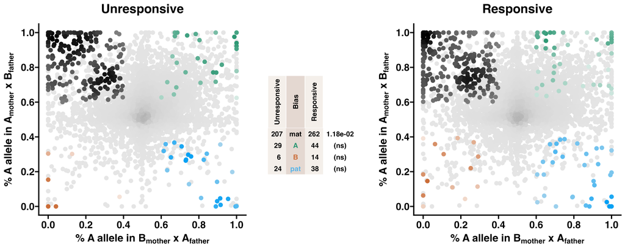

```r
allgenes <- read.table("Amel_HAv3.1_genes.bed",header=F)[,c(4)]
triplot.avgExp <- triplot.plot(unresponsive.collapse,responsive.collapse,
                               "Unresponsive","Responsive",allgenes,
                               LineageA.color="#2d9874",LineageB.color="#cb6c37")
fig1.avgExp <- arrangeGrob(g1.avgExp, triplot.avgExp,
                           g2.avgExp, widths=c(5,2.5,5))
ggsave(file="LB11xW4_avgExp.png", plot=fig1.avgExp, width=15, height=6)
```

### Export PSGE gene lists [`export_PSGE_results`]

```r
export_PSGE_results(unresponsive.plot,responsive.plot,"LB11xW4_PSGEs.csv")
```